# Week 1 Log

### Ray Zhang

#### All line items are assigned a date like a changelog

#### 8/26/2026

- Met up with team in class
- Worked with team to narrow down the topics of interest to 5 through seeing which topics interested at least 1 person
- Discussed with team to rank the five topics in order by how quickly we can come up with solutions for these problems
- Shared needfinding statement email, worked on the template

#### 8/27/2026

- Finished needfinding email by filling out the neccessary info for the template, such as stakeholder name and teammate avalibility
- Submitted needfinding email after confering with team

#### 8/28/2026

- Reviewed feedback from needfinding email, and updated it with the correct name
- Created the week 1 log, weekly project log folder, and Github repo
- Sent needfinding email after review from teammates
- Signed the locker assignments along with teammates
- Selected a role for the team contract. Team contract was drafted from the template, and roles were selected based on current approximate roles
- Reviewed the team contract for submission
- Set up a meeting time (every Friday after class starting next week)
- Logged all the events from August 26th onwards

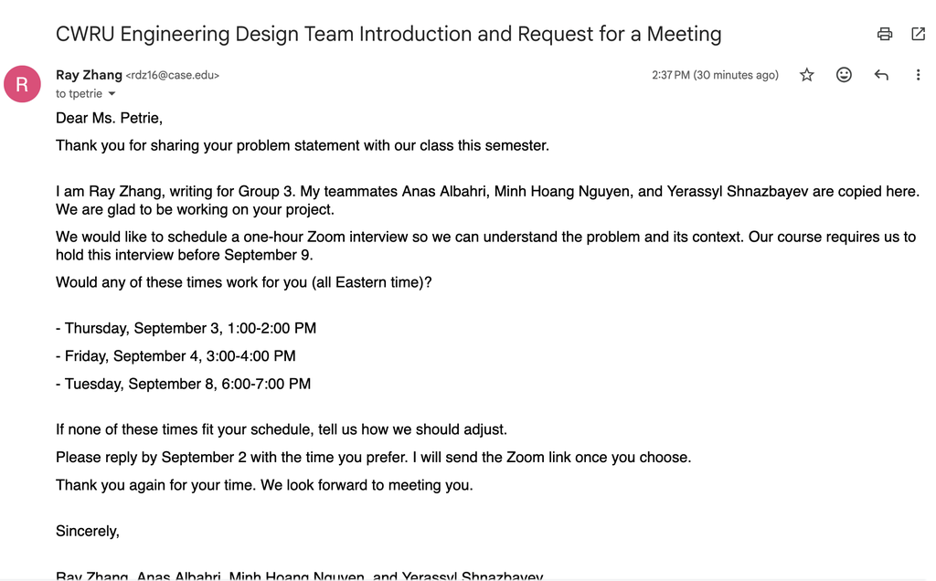

#### 8/29/2026

- Checked emails for stakeholder response

#### 8/30/2026

- Checked emails for stakeholder response